# Assignment: Lab 3: Probability

## Simulations in R

We don’t have any data from a shooter we know to have independent shots.

But it is very easy to simulate such data in R. In a simulation, you set the ground rules of a random process and then the computer uses random numbers to generate an outcome that adheres to those rules.

As a simple example, you can simulate flipping a fair coin with the following.

```r
#Define the outcomes
outcomes <- c("heads", "tails")
sample(outcomes, size = 1, replace = TRUE)
```

```
## [1] "tails"
```

The vector outcomes can be thought of as a hat with two slips of paper in it: one slip says heads and the other says tails.

The function sample draws one slip from the hat and tells us if it was a head or a tail.

Run the second command listed above several times. Just like when flipping a coin, sometimes you’ll get a heads, sometimes you’ll get a tails, but in the long run, you’d expect to get roughly equal numbers of each.

If you wanted to simulate flipping a fair coin 100 times, you could either run the function 100 times or, more simply, adjust the size argument, which governs how many samples to draw (the replace = TRUE argument indicates we put the slip of paper back in the hat before drawing again). Save the resulting vector of heads and tails in a new object called sim_fair_coin.

```r
sim_fair_coin <- sample(outcomes, size = 1000, replace = TRUE)
#sim_fair_coin
```

To view the results of this simulation, type the name of the object and then use table to count up the number of heads and tails.

```r
table(sim_fair_coin)
```

```
## sim_fair_coin
## heads tails
##   488   512
```

```r
table(sim_fair_coin)/1000
```

```
## sim_fair_coin
## heads tails
## 0.488 0.512
```

Since there are only two elements in outcomes , the probability that we “flip” a coin and it lands heads is 0.5. Say we’re trying to simulate an unfair coin that we know only lands heads 20% of the time. We can adjust for this by adding an argument called prob , which provides a vector of two probability weights.

```r
sim_unfair_coin <- sample(outcomes, size = 10000, replace = TRUE, prob = c(0.2, 0.8))
table(sim_unfair_coin)/10000
```

```
## sim_unfair_coin
##  heads  tails
## 0.1989 0.8011
```

Notice prob=(0.2, 0.8) indicates that for the two elements in the outcomes vector, we want to select the first one, heads, with probability 0.2 and the second one, tails, with probability 0.8.

Antoher way of thinking about this is to think of the outcome space as a bag of 10 chips, where 2 chips are labeled “head” and 8 chips “tail”. Therefore at each draw, the probability of drawing a chip that says “head” is 20%, and “tail” is 80%.

#### 3. In the simulation of flipping the unfair coin 100 times, how many flips came up heads?

_*Read more on the sample function in help. ?sample()_

```r
sim_unfair_coin <- sample(outcomes, size = 100, replace = TRUE, prob = c(0.2, 0.8))
freq100 <- table(sim_unfair_coin)
freq100
```

```
## sim_unfair_coin
## heads tails
##    17    83
```

```r
cat("The number of flips that came up heads is: ", freq100["heads"])
```

```
## The number of flips that came up heads is:  17
```

#### Simulating the Independent Shooter

Simulating a basketball player who has independent shots uses the same mechanism that we use to simulate a coin flip. To simulate a single shot from an independent shooter with a shooting percentage of 50% we type:

```r
outcomes <- c("H", "M")
sim_basket <- sample(outcomes, size = 10, replace = TRUE, prob = c(0.5 , 0.5))
sim_basket
```

```
##  [1] "H" "M" "M" "H" "H" "H" "H" "M" "M" "H"
```

```r
#Frequency of Distribution
table(sim_basket)
```

```
## sim_basket
## H M
## 6 4
```

To make a valid comparison between Kobe and our simulated independent shooter, we need to align both their shooting percentage and the number of attempted shots.

Assign the output of this simulation to a new object called sim_basket.

```r
outcomes <- c("H", "M")
sim_basket <- sample(outcomes, size = 133, replace = TRUE, prob = c(.45, .55))
table(sim_basket)/133
```

```
## sim_basket
##        H        M
## 0.406015 0.593985
```

Note that we’ve named the new vector sim_basket, the same name that we gave to the previous vector reflecting a shooting percentage of 50%.

In this situation, R overwrites the old object with the new one, so always make sure that you don’t need the information in an old vector before reassigning its name.

With the results of the simulation saved as sim_basket, we have the data necessary to compare kobe to our independent shooter. We can look at Kobe’s data alongside our simulated data.

```r
#KOBE
kobe$basket
```

```
##   [1] "H" "M" "M" "H" "H" "M" "M" "M" "M" "H" "H" "H" "M" "H" "H" "M" "M" "H"
##  [19] "H" "H" "M" "M" "H" "M" "H" "H" "H" "M" "M" "M" "M" "M" "M" "H" "M" "H"
##  [37] "M" "M" "H" "H" "H" "H" "M" "H" "M" "M" "H" "M" "M" "H" "M" "M" "H" "M"
##  [55] "H" "H" "M" "M" "H" "M" "H" "H" "M" "H" "M" "M" "M" "H" "M" "M" "M" "M"
##  [73] "H" "M" "H" "M" "M" "H" "M" "M" "H" "H" "M" "M" "M" "M" "H" "H" "H" "M"
##  [91] "M" "H" "M" "M" "H" "M" "H" "H" "M" "H" "M" "M" "H" "M" "M" "M" "H" "M"
## [109] "H" "H" "H" "M" "H" "H" "H" "M" "H" "M" "H" "M" "M" "M" "M" "M" "M" "H"
## [127] "M" "H" "M" "M" "M" "M" "H"
```

```r
#INDEPENDENT SHOOTER
sim_basket
```

```
##   [1] "M" "M" "M" "M" "H" "H" "H" "M" "H" "H" "M" "M" "M" "H" "H" "H" "H" "H"
##  [19] "M" "M" "M" "H" "M" "M" "H" "M" "M" "H" "M" "M" "M" "M" "M" "M" "M" "H"
##  [37] "M" "H" "H" "M" "M" "H" "M" "H" "M" "M" "M" "H" "M" "H" "H" "M" "H" "M"
##  [55] "M" "H" "M" "H" "H" "M" "M" "M" "H" "M" "M" "H" "H" "H" "H" "M" "M" "H"
##  [73] "M" "H" "M" "H" "M" "M" "M" "M" "M" "H" "M" "M" "M" "H" "H" "H" "M" "M"
##  [91] "H" "M" "M" "M" "H" "M" "H" "M" "M" "M" "H" "M" "H" "H" "M" "M" "M" "H"
## [109] "M" "M" "M" "M" "H" "H" "M" "M" "M" "H" "M" "M" "M" "H" "H" "M" "M" "H"
## [127] "M" "H" "M" "M" "H" "H" "H"
```

Both data sets represent the results of 133 shot attempts, each with the same shooting percentage of 45%. We know that our simulated data is from a shooter that has independent shots. That is, we know the simulated shooter does not have a hot hand. Each shot in an independent computer generated random number following out hit probability weight.

#### COMPARE & ANALYZE THE TWO. CONCLUSIONS:

```r
sim_streaks <- calc_streak(sim_basket)
table(sim_streaks)
```

```
## sim_streaks
##  0  1  2  3  4  5
## 46 22  7  3  1  1
```

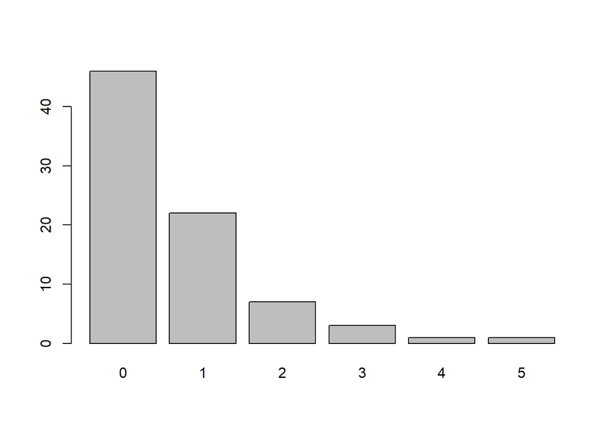

```r
barplot(table(sim_streaks))
```

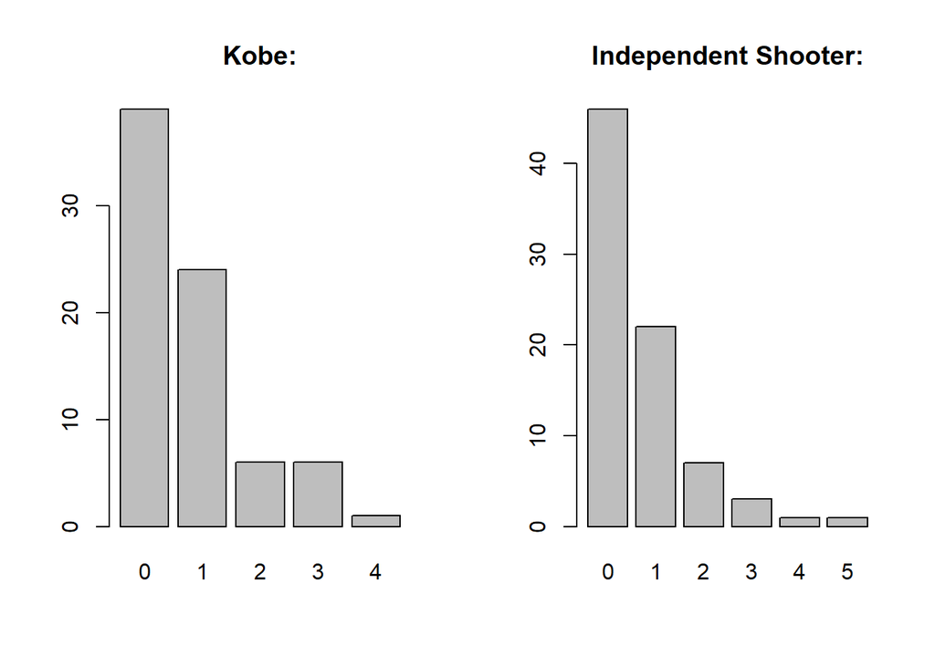

```r
#KOBE'S AND INDEPENDENT SHOOTER BARPLOTS
par(mfrow = c(1, 2))

#KOBE
barplot(dist_tab, main = "Kobe:")

#INDEPENDENT SHOOTER
barplot(table(sim_streaks), main = "Independent Shooter:")
```

*Comparing the two Frequency of Distribution bar plots, we may see that the two plots have a similar shape, which means their distribution is right skewed, or, they both have long right tail.*

*Finally, we may conclude that Kobe’s performance against Orlando Magic was not a hot hand, because the distribution of the streaks are similar to the distribution of a simulated shooter whose shots are independent and therefore, the shooter does not have a right a hand.*

Describe the distribution of streak lengths. What is the typical streak length for this simulated independent shooter with a 45% shooting percentage? How long is the player’s longest streak of baskets in 133 shots?

```r
#Typical streak for independent shooter
table(sim_streaks)
```

```
## sim_streaks
##  0  1  2  3  4  5
## 46 22  7  3  1  1
```

```r
cat("The typical streak for the independent shooter is: ", names(which.max(table(sim_streaks))), "\n")
```

```
## The typical streak for the independent shooter is:  0
```

```r
cat("The longes streak of baskets from the simulated independent shooter is: ", max(names(table(sim_streaks))))
```

```
## The longes streak of baskets from the simulated independent shooter is:  5
```

If you were to run the simulation of the independent shooter a second time, how would you expect its streak distribution to compare to the distribution from the question above? Exactly the same? Somewhat similar? ?Totally different Explain your reasoning.

```r
#Let's run the simulation of the independent shooter one more time, to see the results:
sim_basket2 <- sample(outcomes, size = 133, replace = TRUE, prob = c(.45, .55))
sim_streaks2 <- calc_streak(sim_basket2)
table(sim_basket2)/133
```

```
## sim_basket2
##         H         M
## 0.3834586 0.6165414
```

```r
table(sim_streaks2)
```

```
## sim_streaks2
##  0  1  2  3  5
## 51 20  7  4  1
```

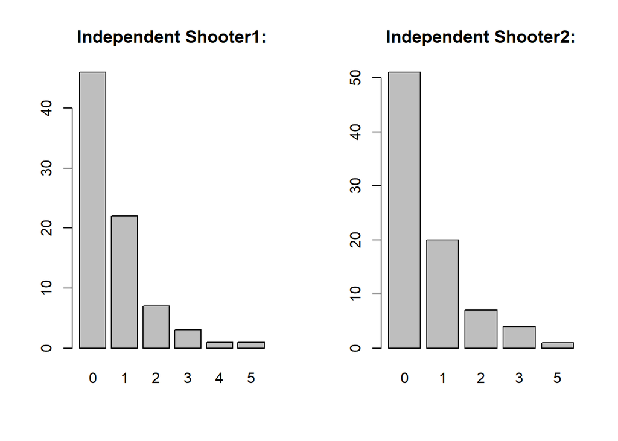

```r
#Plot of the two simulations of the independent shooter
par(mfrow = c(1, 2))
barplot(table(sim_streaks), main = "Independent Shooter1:")
barplot(table(sim_streaks2), main = "Independent Shooter2:")
```

*Based on the results we see from this simulation, we may conclude that the outputs are very similar, they are not exactly the same because of the nature of randomization that the function sample() has. But, it follows the probabilities we set as 0.45 for “H” (Hit shot) and 0.55 for “M” (Missed shot).*

How does Kobe Bryant’s distribution of streak lengths compare to the distribution of streak lengths for the simulated shooter? Using this comparison, do you have evidence that the hot hand model fits Kobe’s shooting patterns? Explain.

*Kobe Bryant’s distribution of streak lengths are very similar to both simulations run for the simulated independent shooter. Using this comparison, and considering the independent shooter has not a hot hand because of the independent shots premise, we have statistical evidence to say that Kobe Bryant’s did not have a hot hand when he played against the Orlando Magic in 2009 NBA finals.*